# Oil Spill Analysis

### 3.0.2 Specific Otter’s Weight before and after the Exxon Oil Spill

We have already looked to see if the general weight of the captured sea otters were significantly different before and after the Exxon oil spill, but now we’d like to see if there were any regional differences between the weights.

#### 3.0.2.1 Creating Plots

As shown below, the West Aleutians are one of the only sites where there were otters captured both before and after the oil spill. As such, we will be analyzing this region of Alaska.

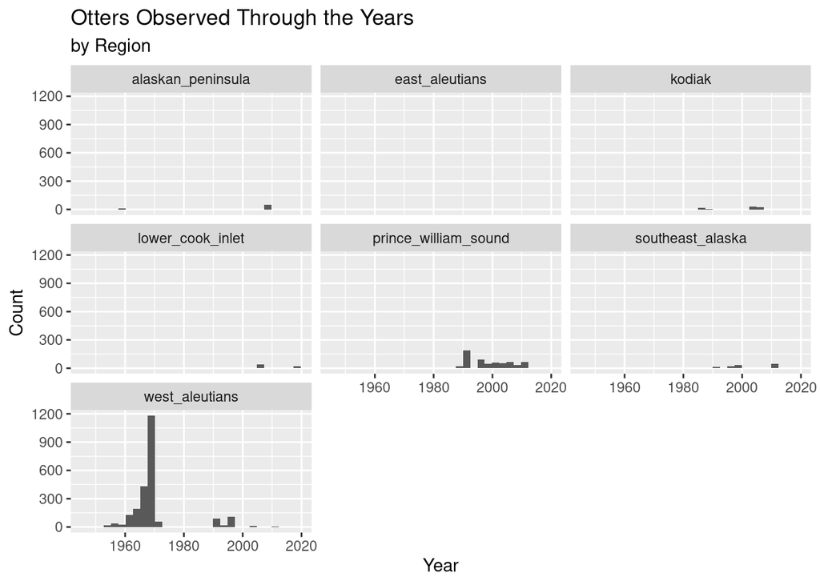

```r
seot %>%
  filter(FINAL_AGE > 4|AGE_CATEGORY > 6) %>%
  ggplot(mapping = aes(x = YEAR)) +
  geom_histogram() +
  facet_wrap(~REGION) +
  labs(title = "Otters Observed Through the Years",
       subtitle = "by Region",
       x = "Year",
       y = "Count")
```

```r
seot_west_aleutians <- seot %>%
  filter(REGION == "west_aleutians")
```

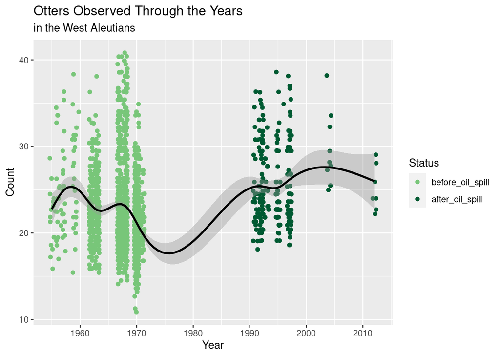

```r
seot_west_aleutians %>%
  filter(FINAL_AGE > 4|AGE_CATEGORY > 6) %>%
  ggplot(mapping = aes(y = WEIGHT, x = YEAR, color = oil_spill)) +
  geom_jitter() +
  scale_color_manual(values = c("#78c679", "#005a32")) +
  geom_smooth(color = "black") +
  labs(title = "Otters Observed Through the Years",
       subtitle = "in the West Aleutians",
       x = "Year",
       y = "Count",
       color = "Status")
```

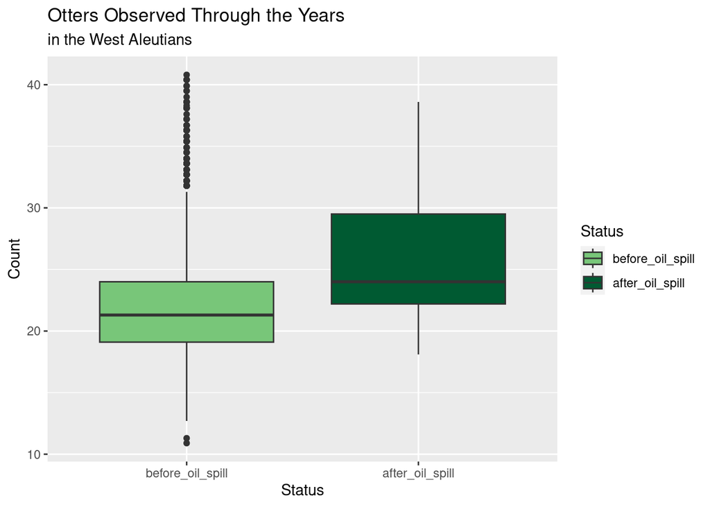

```r
seot_west_aleutians %>%
  filter(FINAL_AGE > 4|AGE_CATEGORY > 6) %>%
  ggplot(mapping = aes(y = WEIGHT, x = oil_spill, fill = oil_spill)) +
  scale_fill_manual(values = c("#78c679", "#005a32")) +
  geom_boxplot() +
  labs(title = "Otters Observed Through the Years",
       subtitle = "in the West Aleutians",
       x = "Status",
       y = "Count",
       fill = "Status")
```